# Yorkshire Fog

Brad Duthie

2026-08-13

> **In this activity, you will learn how to estimate parameters that affect population growth rates, including species interactions. You will use an [online video game](https://ecoknowgames.github.io/Yorkshire_fog/) to simulate the processes of doing experiments in an experimental garden, then applying what you’ve learnt to manage the spread of an invasive species. The assignment will be a 900-1100 word report. Instructions for the report are at the end of this document, but will need to work through the full activity to know how to write it.**

# Background biology

Predicting how species abundances change over time in complex ecosystems is notoriously difficult. We can use mathematical models to better understand how these complex systems change (Caswell 1988), but these models necessarily rely on simplifying assumptions that limit how effective they are at prediction. Predictive models have parameters; these are numbers that determine how the model behaves and the predictions that it makes. Parameter values describe some aspect of the system, such as the carrying capacity (*K*) or intrinsic growth rate (*r*) of a population. Collecting data to estimate parameter values can be costly and time consuming, and uncertainties like measurement error will limit how certain we can be about the true value of any parameter that we estimate. Despite these challenges, predicting ecological change is critical for conserving biodiversity and managing species.

In this activity, we will investigate the ecosystem dynamics of three competing grassland species. We will use a video game to simulate the process of conducting experiments to estimate three parameter values:

1. Species carrying capacities $\left(K\right)$
2. Species intrinsic population growth rates $\left(r\right)$
3. Interactions between species $\left(\alpha\right)$

Using the data collected from these experiments, we will apply what we have learnt to a simulation of species invasion in the Pacific Northwest of North America. Your goal will be to develop a clear management plan to control the spread of the invasive species.

# Plant community

There are 3 species in the plant community of interest: Yorkshire fog (*Holcus lanatus*; Figure 1A), white clover (*Trifolium repens*; Figure 1B), and common bent (*Agrostis capillaris*; Figure 1C). All three of these species are native to the United Kingdom, but they are also invasive to several parts of the world, including New Zealand, Australia, and the Pacific Northwest of North America. While all three species are invasive in these areas, Yorkshire fog is especially problematic. It is a fast-growing weed that forms a thick monoculture with severe effects on soil chemistry and local insect biodiversity.

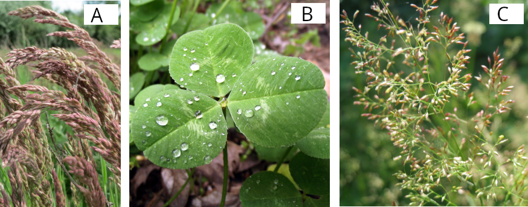

**Figure 1**: Three species of plants, all of which are native the the United Kingdom but invasive to various other parts of the world: (A) Yorkshire fog (*Holcus lanatus*), (B) white clover (*Trifolium repens*), and (C) common bent (*Agrostis capillaris*). All images are in the public domain

We will simulate the management of Yorkshire fog where it is invasive in Olympic National Forest and parts of Vancouver Island (Figure 2). The goal will be to mitigate the negative effects of its invasion by lowering its abundance as much as possible.

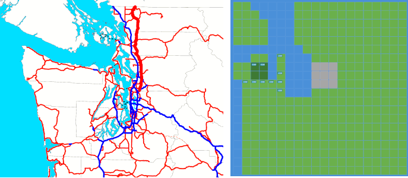

**Figure 2**: Map of the Pacific Northwest including northwestern Washington and the lower part of Vancouver island. The left panel shows a close up of this region as seen on a map, while the right panel shows it as it is seen in the game with some Yorkshire fog shown on the west coast. All images are in the public domain.

In this assignment, you will work through the game environment to collect data. You can start interacting with the game by going to the following website:

> https://EcoKnowGames.github.io/Yorkshire_fog

This game is built using the [EcoKnowGames](https://ecoknowgames.github.io/) creator. This software was built by an [interdisciplinary team](https://ecoknowgames.github.io/people.html) of researchers at the University of Stirling. It allows researchers to build video games that are underpinned by realistic, scientifically valid models and use them to communicate models and collect data about how people play the game. This activity will not collect any data from real plants; we will use the game as a tool for engaging with a simulation of the plant community described above. Parameter values are derived from real data-data driven models (Dormann 2008), but some details about the system have been changed for pedagogical reasons.

# Getting started with the game

When you first click on the [game link](https://EcoKnowGames.github.io/Yorkshire_fog), you will see the EcoKnowGames Creator screen. Click ‘Play’ to get started. From there, you have two options to play: Garden Experiments and Yorkshire Fog (Figure 3). We will start with Garden Experiments, so click the Play button to the right.

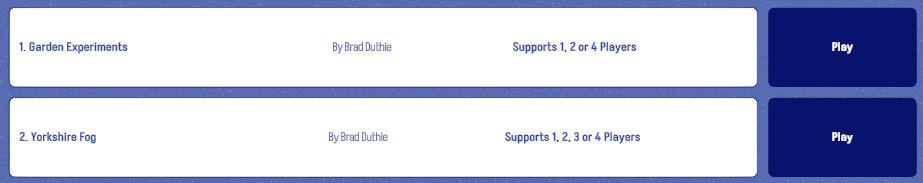

**Figure 3**: Game Scenario options

You will then be prompted with the player setup menu. Type your name in as Player 1, then click ‘Set’. We only need one player, so after you have input your name, click the ‘Start Game’ button below. You will be presented with a grid of squares (Figure 4). The caption of Figure 4 explains what the different menus are on the game screen; not all of these will be important (you can ignore the Inventory entirely).

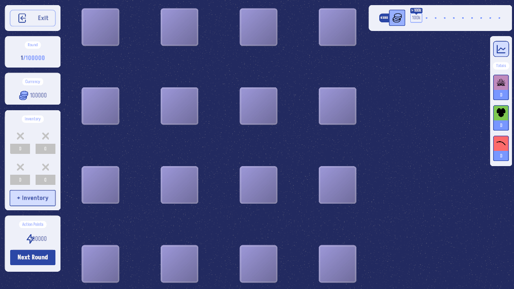

**Figure 4**: A screenshot of the Garden Experiments scenario of the EcoKnowGames video game simulating interactions among three species. The left menu includes the time step (i.e., ‘round number’), currency, inventory status, and an option in the lower left to move to the next time step (‘Next Round’). The upper right panel shows win conditions, while the panel to the far right shows buttons associated with each species. You can click these buttons to plant (‘Introduce’) new seedlings or remove them (‘Harvest’) from the plot.

Each of the light purple squares is a small plot of land. The exact size is not important, but you can picture each square in Figure 4 as roughly 3 metres in length on each side. We can plant as much of each plant as we want in a plot, and plots are separated, so they will not interfere with each other (i.e., there is no dispersal among plots).

To get started, we can work out the carrying capacity (*K*) and the population growth rate (*r*) of common bent (*A. capillaris*). The next sections will show how to do this and explain the game mechanics and any calculations that you need to do.

## Carrying capacity of common bent

The number of plants that can exist on a plot must be finite. At some point, a plant species will run out of space or nutritional resources, so its population size cannot grow forever. The carrying capacity (*K*) of a plot is the maximum number of plants that it can support.

To figure out the carrying capacity of a plot, we can plant some seedlings and let the population grow to its maximum number of common bent plants. To get started, click on the purple button at the top of the far right menu of the screen. You will see a new menu pop up with ‘Agrostis_capillaris’ in small font at the top and the buttons ‘Harvest’ and ‘Introduce’. Click on ‘Introduce’, then click on any two plots in the garden. The game allows you to introduce as many plants as you want, but 10 is a good low number to use as a starting point. Click the blue ‘Introduce’ button to put 10 plants in each plot (Figure 5).

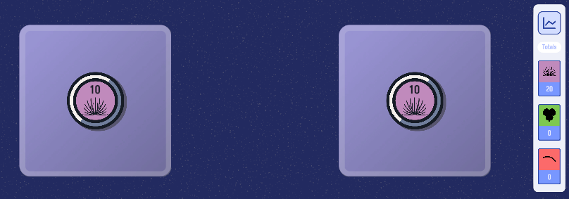

**Figure 5**: A screenshot of the Garden Experiments scenario of the EcoKnowGames video game with 10 common bent plants added to two separate plots.

Click the blue ‘Next Round’ button in the lower left and see what happens. You should see the number of individuals in each plot increase by 3 (from 10 to 13). Keep clicking ‘Next Round’ and watch the population grow. After about 35 rounds, you should see the population size stabilise at 2038. The carrying capacity of a single plot for common bent is therefore $K_{Ac} = 2038$.

## Intrinsic growth rate of common bent

Working out intrinsic growth rate (*r*) takes a few more steps. Intrinsic growth rate measures how fast a population will grow per individual (i.e., per capita) when there is nothing to slow it down (Rockwood 2006). That is, *r* is what population growth will be in the absence of any resource limitations or effects of competition or predation (i.e., in the absence of density-dependent effects). We can estimate *r* by measuring population growth when a species is rare, resources are plentiful, and competition and predation are minimised.

Since our plots have a carrying capacity of $K_{Ac} = 2038$, 100 plants is still quite rare (you can imagine a lot of space on the plots for plants to grow). To work out intrinsic growth rate for common bent ($r_{Ac}$), we can seed a plot with 100 individuals, then observe how much the population grows after one round. Click on the purple icon at the top of the far right menu of the screen as you did in the previous section, but this time introduce 100 plants into any empty plot. Once you have added the plants, click ‘Next Round’.

You should see the number of plants on the plot grow from 100 to 134. This means that the population grew by 34 plants. Since we started with 100 plants, for each plant in the population, 34/100 = 0.34 new plants were produced. The *per capita* rate of population growth is therefore estimated to be $r_{Ac} = 0.34$. Note that the population does not continue to grow at this rate when we keep clicking ‘Next Round’. Population growth rate slows down as the population size gets closer to $K_{Ac} = 2038$, and when the population eventually hits $K_{Ac}$, the growth rate is zero. Think about what this means in terms of the ecology; as common bent becomes more abundant on the plot, its growth rate starts to slow down due to effects of its own density (e.g., competition for limited space or nutrients).

## Find r and K for other species

Using the same approach as in the previous two sections, work out intrinsic growth rate for the other two species: white clover (*T. repens*) and Yorkshire fog (*H. lanatus*). If you need more plots in the garden, you can harvest all of the plants on a plot by clicking the species icon in the right menu and choosing ‘Harvest’, or you can Exit to the main menu (upper left button) then return with a fresh set of plots.

> **Fill in the estimated parameter values using Table 1 below.**

**Table 1**: Parameter estimates for common bent (*A. capillaris*), white clover (*T. repens*), and Yorkshire fog (*H. lanatus*).

| Parameter | *A. capillaris* | *T. repens* | *H. lanatus* |
| --- | --- | --- | --- |
| K | 2038 |  |  |
| r | 0.34 |  |  |

Do not worry about your estimates being exact. A real field experiment is [always going to be limited](https://bradduthie.github.io/stats/Chapter_6.html) in how accurately ecological parameter values can be measured. Every measurement includes some uncertainty, and no model can predict what will happen with perfect accuracy. Nevertheless, since we have *r* and *K*, we can use it to parameterise the classical logistic growth equation (Gotelli 2001),

$$\frac{dN}{dt} = rN\left(1 -
\frac{N}{K}\right).$$

We can substitute our values of r = 0.34 and K = 2038 to predict population change for the common bent,

$$\frac{dN}{dt} = 0.34 \times N \left(1 -
\frac{N}{2038}\right).$$

If we substitute some number in for N, then we should be able to predict the change in population size for the next time step. For example, we can predict how much population size will change when N = 1000,

$$\frac{dN}{dt} = 0.34 \times 1000 \left(1
- \frac{1000}{2038}\right).$$

If we do the above calculation, then we find the change in population size equals about 173.17. To see how well this model does at predicting the change in population size when N = 1000, place 1000 common bent plants into an empty cell, then click ‘Next Round’. You will see the new population size is 1187, so it grew by 187, which is a bit higher than our predicted 173.17, but not actually that bad in terms of ecological predictions. Try this for the other two species to see if the predictions are any closer, and think about what might cause a difference between the model prediction and what actually happens in the field.

## Interactions between species

Since we now know the carrying capacities and intrinsic growth rates of each species, we can predict how each population will change in a monoculture. But we also want to know how species affect one another. To work this out, we need interaction coefficients.

An interaction coefficient $\alpha_{ij}$ tells us the effect that an individual of species $j$ has on the population growth of an individual of species $i$ (Chesson 2000). In other words, $\alpha_{ij}$ defines the per capita effect of the *abundance* of $j$ on the population *growth* of $i$. If, for example, $\alpha_{ij} = -1$, that means that for each additional $j$ in a population, the growth rate of $i$ decreases by 1 (this would be *very* strong competition). If $\alpha_{ij} = 0$, then $j$ has no effect on $i$, and if $\alpha_{ij} > 0$, then $j$ has a positive effect on the growth of $i$ (e.g., because the two species are mutualists, or because $i$ is a predator of $j$). This might be a bit abstract at first, but the logic will make more sense when we work out actual numbers using the simulation.

We can start by working out the effect of white clover (*T. repens*) on common bent (*A. capillaris*), $\alpha_{Ac,Tr}$. In words, **what we are trying to do is figure out how much the population growth rate of common bent changes for each additional white clover that we add.**

We already know that the population growth rate of common bent is $r_{Ac} = 0.34$. We worked this out in a previous section. To see how much this growth rate is changed by white clover, we can set up a new experimental plot in the Garden Experiments game. Introduce 100 common bent individuals into a garden plot. Next, add 1000 white clover in the same plot. If white clover has an effect on the population growth rate of common bent, then we will no longer see common bent grow from a population size of 100 to 134 as before; something will change. Click ‘Next Round’ and see that the population size of common bent grows from 100 to 124. That is 10 fewer individuals than when common bent is growing on its own, so the population growth rate of common bent is now 24 / 100 = 0.24 instead of 0.34.

Clearly the white clover decreased the population growth rate of common bent, so how do we calculate $\alpha_{Ac,Tr}$? The change in common bent growth was 0.24-0.34 = -0.1, and there were 1000 white clover in the plot. This means that each white clover changed the growth rate by -0.1/1000 = -0.0001, so $\alpha_{Ac,Tr} = -0.0001$. That seems like a small number, but think about what it means. **For each white clover in the plot, a the population growth rate of common bent decreased by 0.0001**.

Species effects are not necessarily symmetrical. The effect that white clover has on common bent might be different to the effect that common bent has on white clover. With this in mind, use the same experimental technique as above to work out the interaction coefficients for all combinations of species.

> **Fill in the estimated interaction coefficients in Table 2 below. Species in a row are affected by species in a column (the effect of *T. repens* on *A. capillaris* calculated above is already included).**

When you fill in the table, **use at least 6 decimal places** for each $\alpha$ value.

**Table 2**: Interaction coefficients for all pairwise combinations of common bent (*A. capillaris*), white clover (*T. repens*), and Yorkshire fog (*H. lanatus*).

|  | *A. capillaris* | *T. repens* | *H. lanatus* |
| --- | --- | --- | --- |
| *A. capillaris* | -0.000167 | -0.000100 |  |
| *T. repens* |  | -0.000155 |  |
| *H. lanatus* |  |  | -0.000166 |

Notice that the diagonal of Table 2 already includes the effect of each species on itself. For example, $\alpha_{Ac,Ac} = -0.000167$. **What might this number mean, and how would you estimate it?** (hint: you could use an in-game experiment, but you do not need to – you already have all of the information you need to calculate $\alpha_{Ac,Ac}$ from Table 1).

Tables 1 and 2 give us all of the parameter values that we need to predict population growth when two species are competing. We can use the **generalised Lotka-Volterra** equation[^1] to predict what population size (N) will be in the next time step (t+1),

$$N_{i}(t+1) = N_{i}(t) +
N_{i}(t)\left(r_{i} + \alpha_{ii}N_{i}(t) +
\alpha_{ij}N_{j}(t)\right).$$

We will not force you to do this, but it might be useful! If you are feeling brave, you can give it a try! You should be able to predict the next population size of a species $i$ ($N_{i}(t+1)$) given its current population size ($N_{i}(t)$), its population growth rate ($r_{i}$), and the per capita effect of its own density ($\alpha_{ii}$) and that of another species ($\alpha_{ij}$) on its growth rate (remember that $\alpha$ values are negative, so you will actually be subtracting inside the brackets).

Think about the information that you have worked out in Tables 1 and 2. How might it be useful for predicting and managing the spread of Yorkshire fog (*H. lanatus*) in the presence of the two other species? Before moving to the next section, try using the garden experiment level to test your ideas and see what happens when different combinations of species are on a plot in different abundances. You can always come back to this level as a way to experiment and test your ideas about the community ecology of this system. In the next section, we will move on to managing an outbreak of Yorkshire fog in the Pacific Northwest.

# Yorkshire fog management

In the game level Yorkshire Fog (Figure 3), you are in charge of managing the spread of Yorkshire fog (*H. lanatus*) in the Pacific Northwest of North America. In this (fictional) scenario, its presence has been observed in western Washington, USA. The initial distribution of the species is shown in Figure 6.

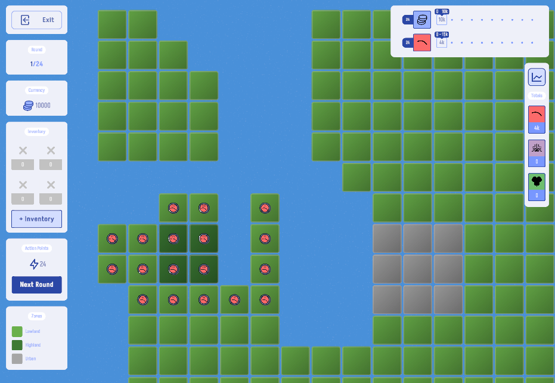

**Figure 6**: The initial map of the game Yorkshire fog, in which players are tasked with minimising the population size of the invasive species.

In this game, you begin with a mostly empty map, but on the west side of the map, you can see that *H. lanatus* (shown in red icons) exists on 18 landscape tiles at various abundances. You start out with 10000 in currency that you can spend to either remove (i.e., ‘harvest’) plants from landscape cells, or to plant new seedlings (i.e., ‘introduce’). Removing established plants is difficult, and therefore costly. Every plant you remove costs 10 in currency. Introducing new plants is easier, and therefore cheaper. Every plant you add costs 2 in currency. The panel in the upper right corner keeps track of two game objectives:

1. Do not exceed your 10000 currency budget
2. Keep the abundance of *H. lanatus* below 15000

You are in charge for 24 months, and each time step is a month. **Do your best to keep the population of *H. lanatus* as low as possible.** You can track your progress by clicking the graph icon in the right panel.

Do not worry about the abundance of any common bent (*A. capillaris*) or white clover (*T. repens*) that you introduce. These species are not considered to be a major concern in this scenario, so you will not be penalised if they become abundant. In this scenario, the invasive Yorkshire fog can spread rapidly from landscape tile to landscape tile, but the other two species will not spread to new tiles.

You can restart the game as many times as you wish. Keep track of what you do and work out the best strategy to manage the spread of the invasive Yorkshire Fog. When you are satisfied that you have a management plan that works, you will write up a 900-1100 word report.

# The Report

You have spent 24 months of your life managing the spread of Yorkshire fog. You now need to write up a 900-1100 word report to guide future managers of this system. In a brief introductory paragraph, provide some background on the system and clearly state the aim of the report. In 2-3 body paragraphs, justify your approach using principles of population and community ecology, and your experience playing the game. If it is helpful, you can refer back to experiments that you did in the Garden Experiments level. You can discuss specific challenges that might arise, including budgetary issues that you faced as a manager. Make sure to cite at least 4 references in your report. Include at least two tables with informative captions: (1) Table 1 listing *K* and *r* parameters, and (2) Table 2 listing interaction coefficients. Also include at least two figures with informative captions: (1) a screenshot showing your map on round 23, and (2) the final plot from the game showing population change over time. Table and figure captions do not count towards the final word count. You are welcome to include additional references, tables, and plots, but it is not necessary. Finally, include a short conclusion paragraph that summarises your management strategy.

# References

Caswell, Hal. 1988. “Theory and Models in Ecology: A Different Perspective.” *Ecological Modelling* 43 (1-2): 33–44.

Chesson, Peter. 2000. “Mechanisms of Maintenance of Species Diversity.” *Annual Review of Ecology and Systematics* 31 (1): 343–66.

Dormann, Carsten F. 2008. “On Community Matrix Theory in Experimental Plant Ecology.” *Web Ecology* 8 (1): 108–15.

Gotelli, Nicholas J. 2001. *A Primer of Ecology*. 3rd ed. Sinauer Associates.

Rockwood, Larry L. 2006. *Introduction to Population Ecology*. Blackwell Publishing.

[^1]: Note, somewhat confusingly, you will see slightly different versions of this equation in the literature. Some authors prefer to scale interaction coefficients by population growth rate or carrying capacity, and this affects how they are interpreted in different situations.